# HWInsurance

Random cashflows

1. Consider a dice flip game, which costs $X. If you get an even number then you earn $10. If you get an odd number then you earn $15. Note that we can simulate the game by using R sample(1:6,size=1) a) Write a R code to simulate the game result after playing 10 times and record the average amount obtained.

```r
num_simulations <- 10


play_game <- function() {
  dice_result <- sample(1:6, size = 1)
  if (dice_result %% 2 == 0) {
    return(10)
  } else {
    return(15)
  }
}


game_results <- replicate(num_simulations, play_game())


average_amount <- mean(game_results)


print(paste("Average amount playing 10 times: $", average_amount))
```

```
[1] "Average amount playing 10 times: $ 12"
```

b) Write a R code to simulate and track the average amount obtained for each of 10000 play times. Explain in detail the obtained figure.

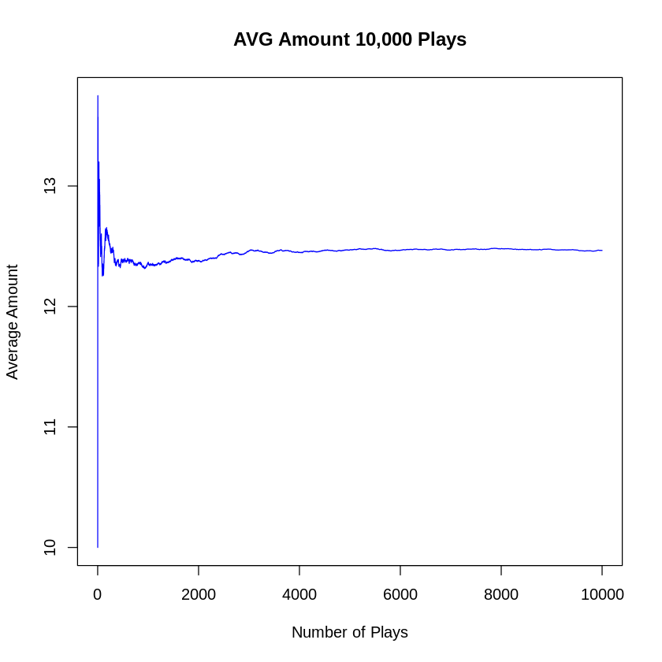

```r
num_simulations <- 10000

play_game <- function() {
  dice_result <- sample(1:6, size = 1)
  if (dice_result %% 2 == 0) {
    return(10)
  } else {
    return(15)
  }
}

game_results <- numeric(num_simulations)
cumulative_averages <- numeric(num_simulations)

for (i in 1:num_simulations) {
  game_results[i] <- play_game()
  cumulative_averages[i] <- mean(game_results[1:i])
}

plot(cumulative_averages, type = "l", col = "blue",
     xlab = "Number of Plays", ylab = "Average Amount",
     main = "AVG Amount 10,000 Plays")
```

c) What is the fair value for $X?

```r
num_simulations <- 10000

play_game <- function() {
  dice_result <- sample(1:6, size = 1)
  if (dice_result %% 2 == 0) {
    return(10)
  } else {
    return(15)
  }
}

game_results <- numeric(num_simulations)
cumulative_averages <- numeric(num_simulations)

for (i in 1:num_simulations) {
  game_results[i] <- play_game()
  cumulative_averages[i] <- mean(game_results[1:i])
}

fair_value <- mean(game_results)

print(paste("The fair value for X is: $", fair_value))
```

```
[1] "The fair value for X is: $ 12.5215"
```

1. Consider a coin flip game, which costs X USD. The player will flip 3 identical coins. Each coin will have two faces: heads or tails. For each coin toss, the probability of obtaining a heads is 0.35. The reward will depend on the number of heads obtained from the flip. The player will obtain a reward 10 if the number of heads is 0. The player will obtain a reward 27 if the number of heads is 1. The player will obtain a reward 15 if the number of heads is 2. The player will obtain a reward 46 if the number of heads is 3. a) Write a R code to simulate the game result after playing 10 times and record the average amount obtained.

```r
num_simulations <- 10

play_game <- function() {

  coin_flips <- rbinom(3, 1, 0.35)
  num_heads <- sum(coin_flips)


  if (num_heads == 0) {
    return(10)
  } else if (num_heads == 1) {
    return(27)
  } else if (num_heads == 2) {
    return(15)
  } else if (num_heads == 3) {
    return(46)
  }
}

game_results <- replicate(num_simulations, play_game())

average_amount <- mean(game_results)

print(paste("Average amount obtained after playing 10 times: $", average_amount))
```

```
[1] "Average amount obtained after playing 10 times: $ 19.7"
```

```r
num_simulations <- 10000

play_game <- function() {
  coin_flips <- rbinom(3, 1, 0.35)
  num_heads <- sum(coin_flips)

  if (num_heads == 0) {
    return(10)
  } else if (num_heads == 1) {
    return(27)
  } else if (num_heads == 2) {
    return(15)
  } else if (num_heads == 3) {
    return(46)
  }
}

game_results <- numeric(num_simulations)
cumulative_averages <- numeric(num_simulations)

for (i in 1:num_simulations) {
  game_results[i] <- play_game()
  cumulative_averages[i] <- mean(game_results[1:i])
}

results_df <- data.frame(
  Play_Number = 1:num_simulations,
  Reward = game_results,
  Cumulative_Average = cumulative_averages
)


head(results_df)
```

A data.frame: 6 × 3

|  | Play_Number <int> | Reward <dbl> | Cumulative_Average <dbl> |
| --- | --- | --- | --- |
| 1 | 1 | 27 | 27.0 |
| 2 | 2 | 27 | 27.0 |
| 3 | 3 | 27 | 27.0 |
| 4 | 4 | 15 | 24.0 |
| 5 | 5 | 27 | 24.6 |
| 6 | 6 | 27 | 25.0 |

c) What is the fair value for $X?

```r
p_heads <- 0.35
p_tails <- 1 - p_heads


p_0_heads <- dbinom(0, 3, p_heads)
p_1_head <- dbinom(1, 3, p_heads)
p_2_heads <- dbinom(2, 3, p_heads)
p_3_heads <- dbinom(3, 3, p_heads)


reward_0_heads <- 10
reward_1_head <- 27
reward_2_heads <- 15
reward_3_heads <- 46


expected_value <- (p_0_heads * reward_0_heads) +
                  (p_1_head * reward_1_head) +
                  (p_2_heads * reward_2_heads) +
                  (p_3_heads * reward_3_heads)

print(paste("The fair value for X is: $", round(expected_value, 2)))
```

```
[1] "The fair value for X is: $ 20.28"
```

Survival rate